# Street Roads

Yuyan Yang

4/1/2022

# Part 1: Solved Example (PO Box):

### Load Packages

```r
library(dcData)
options(dplyr.summarise.inform = FALSE)
library(tidyverse)
```

### Load Data

```r
# Data Resources - North Carolina
# 15000 street addresses of registered voters in Wake County, North Carolina
Addresses <- read.csv("https://mdbeckman.github.io/dcSupplement/data/street-addresses.csv", header = T)

# 900,000 street addresses of Medicare Service Providers
download.file(url="https://mdbeckman.github.io/dcSupplement/data/CMS_ProvidersSimple.rds", destfile = "CMS_ProvidersSimple.rds")
AddressesMPS <- readRDS("CMS_ProvidersSimple.rds") # local copy
```

```r
# sample a few dozen cases
Sample <- Addresses %>%
  sample_n(size = 50)
```

### Step 1 & 2 & 3: Describe a Regex and filter the cases

```r
# 1. The PO Box cases tend to have a substring "PO"
# 2. the regular expression for "PO" is simply `"PO"`
# 3. Find some cases that match:
Matches <-
  Sample %>%
  filter(grepl("PO", address))
```

### Step 4: Retain the cases not match the expression

```r
# 4. Find cases that don't match
Dont <-
  Sample %>%
  filter( ! grepl("PO", address))
```

### Step 5: Examine results

```r
# 5. Find cases of `Matches` that we don't want to match,
# and find cases of `Dont` that we should have matched.
# Inspect Matches
head(Matches)
```

|  | address |
| --- | --- |
| 1 | PO BOX 97191 |
| 2 | PO BOX 10644 |
| 3 | PO BOX 301 |
| 4 | PO BOX 164 |
| 5 | PO BOX 1011 |
| 6 | PO BOX 12172 |

```r
# Inspect Dont
head(Dont)
```

|  | address |
| --- | --- |
| 1 | 83 N WHITNEY ST APT 6 |
| 2 | NCSU BOX 22501 |
| 3 | NCSU BOX 21130 |
| 4 | 850 NORTHCHESTER LN |
| 5 | NCSU BOX 22039 |
| 6 | 1000 GREENWOOD CT |

### Step 6 & 7: Improve or extend the pattern

```r
# 6. Maybe "BOX" might be a better pattern,
# so we'll try that instead.
# Pattern to locate
pattern <- "BOX\\s+(\\d+)"

# Inspect Matches
Matches <-
  Sample %>%
  filter(grepl(pattern, address))

Matches
```

| address |
| --- |
| PO BOX 97191 |
| PO BOX 10644 |
| PO BOX 301 |
| NCSU BOX 22501 |
| NCSU BOX 21130 |
| PO BOX 164 |
| NCSU BOX 22039 |
| PO BOX 1011 |
| PO BOX 12172 |
| PO BOX 99663 |

[output cut: 23 more lines]

```r
# Inspect Dont
Dont <-
  Sample %>%
  filter( ! grepl(pattern, address))

Dont
```

| address |
| --- |
| 83 N WHITNEY ST APT 6 |
| 850 NORTHCHESTER LN |
| 1000 GREENWOOD CT |
| 104 WAKEHURST DR |
| 55 RED LANE |
| 7901 BAYMEADOWS CIR E |
| 1010 TOPSAIL COMMON DR APT 205 |
| 7223 WILDERNESS RD |
| FOUNDERS 42 ST ANTONYS UNIV OXFORD |
| 925 RALEIGH ST |

[output cut: 7 more lines]

### Step 8: Extract info we are looking for

```r
# We'll now use `tidyr::extract()` to pull
# the part of the pattern identified by the extraction parenthesis.
BoxNumbers <-
  Sample %>%
  filter(grepl(pattern, address)) %>%
  tidyr::extract(address, into = "boxnum", regex = pattern)

head(BoxNumbers, 10)
```

|  | boxnum |
| --- | --- |
| 1 | 97191 |
| 2 | 10644 |
| 3 | 301 |
| 4 | 22501 |
| 5 | 21130 |
| 6 | 164 |
| 7 | 22039 |
| 8 | 1011 |
| 9 | 12172 |
| 10 | 99663 |

# Part 2: Back to the Streets

## Your turn 1: explain each line of code in English (commented code)

```r
# Store a pattern of a street name identifier, ST or RD or ROAD
pattern <- "(ST|RD|ROAD)"

# Output the results to a data frame named LeftOvers
LeftOvers <-

  # USE addresses as the input data frame
  Addresses %>%

  # excluded address with pattern ('ST' or 'RD' or 'ROAD')
  filter( ! grepl(pattern, address),

          # excluded address end with (1 space + 'APT' or 'UNIT' + 1 space + 1 or more digits)
          ! grepl("\\sAPT|UNIT\\s[\\d]+$", address),

          # excluded address with pattern ('BOX' or 'BX')
          ! grepl("BOX|BX", address))

# Inspect the result to find out which street name identifiers need to be further include in the pattern
head(LeftOvers, 10)
```

|  | address |
| --- | --- |
| 1 | 2117 MARINER CIRCLE |
| 2 | 101 EPPING WAY |
| 3 | 04-I ROBIN CIRCLE |
| 4 | NCSU B0X 15637 |
| 5 | 4719 BROWN TRAIL |
| 6 | 130 THE WINERY |
| 7 | 5250 ADAMS AVE |
| 8 | 7416 IVY LEAGUE LN |
| 9 | 12629 WATERMAN DR |
| 10 | HMIA-267 |

## Your Turn 2: expand to match several more pattern

ReadMe:

- What I will do is first combine both data sets (Addresses and AddressesMPS)
- Then I will go through the workflow (Step 1 to Step 8)
- I will define a simple (not very accurate) regular expression (break down components of addresses) to find out the ranking of popular street identifiers (their counts is not accurate due the inaccurate regex but it can provide a great big picture of popularity)
- Then I will use the top (at least 12) street identifiers to match in the original dataset to find out accurate counts (I will manually inspect to exclude the terms that is not street identifiers)
- Then, I will generate table and plots

### Combine two datasets

```r
# filter AddressesMPS with only address
AddressesMPS <- AddressesMPS %>%
  select(address)

# row bind two files
Combine <- rbind(Addresses, AddressesMPS)
```

### Step 1: Describe a pattern

For address, I think it will start with some numbers. Then, there will be a space. After space, it will have characters (name of street). After another space, there are the related words we are looking for(streets, lanes, avenues, etc).

### Step 2: Translate step 1 to regular expression

```r
# start with 1 or more digits(street number) + 1 or more space + 1 or more alphabetic character(street name) + 1 or more space + 1 or more alphabetic characters(road-related words)
pattern <- "^\\d+\\s+[A-z]+\\s+[A-z]+"
```

### Step 3: Filter to retain the cases that match the expression

```r
# filter to retain the cases that match the regular expression, get rid of non-address (like PO box etc.)
Match <- Combine %>%
  filter(grepl(pattern,address))
```

### Step 4: Retain the cases that do not match the expression

```r
# filter to retain the cases that do not match the expression (like PO box etc.)
NotMatch <- Combine %>%
  filter(!grepl(pattern,address))
```

### Step 5: Examine step 3 and step 4 to identidy shortcomings

```r
# examine matches
head(Match)
```

|  | address |
| --- | --- |
| 1 | 2117 MARINER CIRCLE |
| 2 | 101 EPPING WAY |
| 3 | 5102 ECHO RIDGE RD |
| 4 | 5007 PURITAN RD |
| 5 | 4800 WESTERN BLVD |
| 6 | 2801 NELLOWOOD ST |

```r
tail(Match) # no obvious issue
```

|  | address |
| --- | --- |
| 769050 | 1325 HULL RD |
| 769051 | 19735 GERMANTOWN RD |
| 769052 | 195 PEABODY ST |
| 769053 | 1355 FOUR MILE DR |
| 769054 | 1410 OAK ST |
| 769055 | 8260 ATLEE RD |

```r
# examine not match
head(NotMatch)
```

|  | address |
| --- | --- |
| 1 | PO BOX 58592 |
| 2 | PO BOX 37218 |
| 3 | PO BOX 37218 |
| 4 | PO BOX 1953 |
| 5 | PO BOX 132 |
| 6 | PO BOX 360 |

```r
tail(NotMatch) # issue: some address with non-traditional format were excluded
```

|  | address |
| --- | --- |
| 156028 | 111-115 GATES AVE |
| 156029 | 1601 NW 12TH AVE # 803 |
| 156030 | 2901 HIGHWAY 412 E |
| 156031 | 1015 NW 22ND AVE |
| 156032 | 15330 IH 35 N |
| 156033 | 1100 9TH AVE |

### Step 6: Improved or extend pattern

```r
# start with 1 or more digits(street number) + 1 or more space + 1 or more alphabetic character(street name) + 1 or more space + 1 or more alphabetic characters(road-related words)
# change 1 or more alphabetic character(street name) to '\\w' to include street name which has numbers (like 7th ave, etc.)
pattern <- "^\\d+\\s+\\w+\\s+[A-z]+"

# filter to retain the cases that match the regular expression, get rid of non-address (like PO box etc.)
Match <- Combine %>%
  filter(grepl(pattern,address))

# filter to retain the cases that do not match the expression (like PO box etc.)
NotMatch <- Combine %>%
  filter(!grepl(pattern,address))
```

```r
# examine matches
head(Match)
```

|  | address |
| --- | --- |
| 1 | 2117 MARINER CIRCLE |
| 2 | 101 EPPING WAY |
| 3 | 5102 ECHO RIDGE RD |
| 4 | 5007 PURITAN RD |
| 5 | 4800 WESTERN BLVD |
| 6 | 2801 NELLOWOOD ST |

```r
tail(Match) # no obvious issue
```

|  | address |
| --- | --- |
| 805135 | 19735 GERMANTOWN RD |
| 805136 | 195 PEABODY ST |
| 805137 | 1355 FOUR MILE DR |
| 805138 | 1410 OAK ST |
| 805139 | 1100 9TH AVE |
| 805140 | 8260 ATLEE RD |

```r
# examine not match
head(NotMatch)
```

|  | address |
| --- | --- |
| 1 | PO BOX 58592 |
| 2 | PO BOX 37218 |
| 3 | PO BOX 37218 |
| 4 | PO BOX 1953 |
| 5 | PO BOX 132 |
| 6 | PO BOX 360 |

```r
tail(NotMatch) # some weird format address were still excluded, but it's hard to extend this time because it will make matches data inaccurate if we further expand regular expression
```

|  | address |
| --- | --- |
| 119943 | 6701 S. MINNESOTA AVE |
| 119944 | 111-115 GATES AVE |
| 119945 | 1601 NW 12TH AVE # 803 |
| 119946 | 2901 HIGHWAY 412 E |
| 119947 | 1015 NW 22ND AVE |
| 119948 | 15330 IH 35 N |

### Step 7: Repeated step 1 ad 6

Repeat process in step 6.

### Step 8: Put extaction parenthesis around the parts of regular expression that contain the information we wat

```r
# adding parenthesis around last 1 or more alphabetic characters because they are the road-related words
extraction <- "^\\d+\\s+\\w+\\s+([A-z]+)"

# using extract() function to extract the road-related words
street <- Match %>%
  tidyr::extract(address, into = "road", regex = extraction)
```

### Find out the top 20 most popular street identifiers

```r
# rank the street identifiers in descending orders by count
# only show the top 20 street name identifiers
street %>%
  group_by(road) %>%
  summarise(count = n()) %>%
  arrange(desc(count)) %>%
  top_n(20)
```

| road | count |
| --- | --- |
| ST | 109668 |
| AVE | 102931 |
| RD | 68463 |
| DR | 50423 |
| BLVD | 32616 |
| MAIN | 13039 |
| STREET | 12526 |
| PKWY | 8585 |
| CENTER | 8540 |
| PARK | 8516 |

[output cut: 10 more lines]

In the top 20, it is obvious that ‘MAIN’, ‘CENTER’, ‘PARK’, ‘Medical’ are not street identifiers. So, I will exclude them and include everything else in top 20 in the final pattern.

### Providing a Table in descending order of popularity for the street name identifiers

```r
# define our final pattern, which includes 16 street identifiers. They has 1 or more space before it. Also, it ends right after identifiers. By including at least 1 space before identifiers, we are making sure the identifiers we extract are actual street identifiers instead of characters of a street name. By end right after identifiers, we exclude address with units or apartments. It's an disadvantage, but it can make sure every identifier i got is an actual road-identifier instead of being parts of a word.
final_pattern <- "\\s+(ST|AVE|RD|DR|BLVD|STREET|PKWY|ROAD|LN|WAY|HWY|AVENUE|DRIVE|HIGHWAY|PL|CT)$"

# match the final pattern with address and extract road identifiers
popularity <-
  Combine %>%
  filter(grepl(final_pattern, address)) %>%
  tidyr::extract(address, into = "identifier", regex = final_pattern)

# turn road identifiers into descending order of popularity
popularity <- popularity  %>%
  group_by(identifier) %>%
  summarise(count = n()) %>%
  arrange(desc(count))

popularity
```

| identifier | count |
| --- | --- |
| ST | 195204 |
| AVE | 145720 |
| RD | 124008 |
| DR | 84395 |
| BLVD | 59301 |
| STREET | 19680 |
| PKWY | 14360 |
| ROAD | 11903 |
| HWY | 10622 |
| LN | 10410 |

[output cut: 6 more lines]

### Use ggplot to contrusct a bar chart in descedning order of popularity

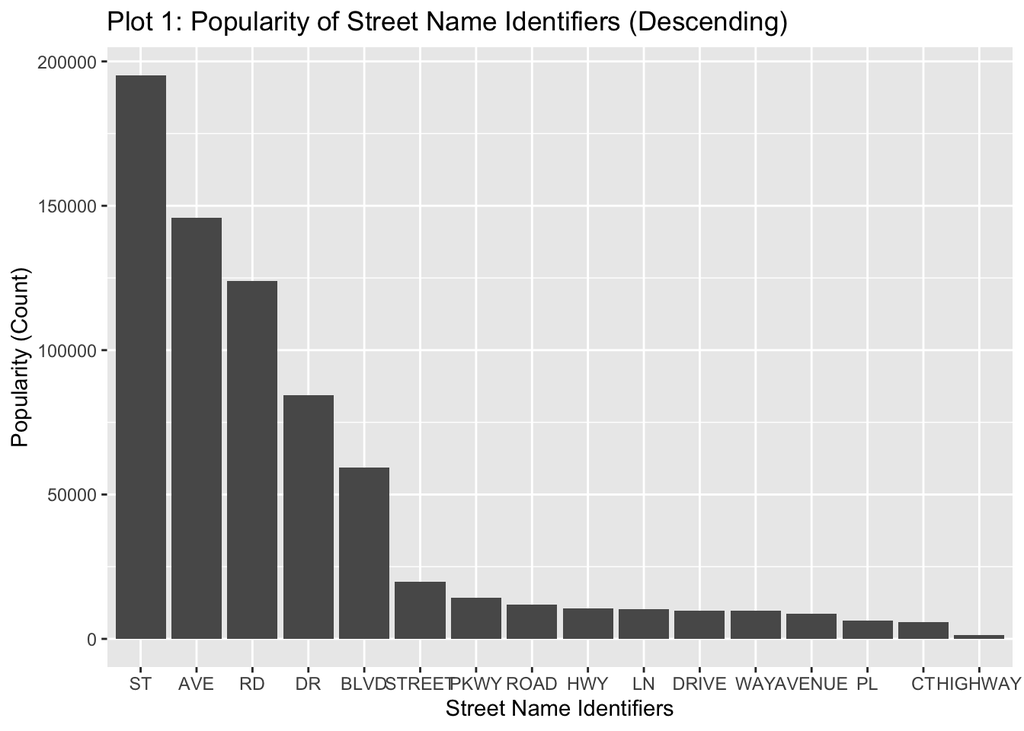

```r
# bar chart in descending order of popularity
popularity %>%
  ggplot(aes(x=reorder(identifier,-count),y=count)) +
  geom_bar(stat ='identity') +
  ggtitle('Plot 1: Popularity of Street Name Identifiers (Descending)') +
  xlab('Street Name Identifiers') +
  ylab('Popularity (Count)')
```